# Multi-Document QA with LLMs (GPT-3.5/4) and Neural Reranking

GitHub: [Retrieval-Augmented Generation & Dynamic Prompting with LLMs for better Q&A](https://github.com/sakshamprakash01/Retrival-Augmented-Generation-Dynamic-Prompting-LLMs-for-better-Q-A)

This will implement a retrieval + QA system. The input to the system is multiple documents and a question. The output is an answer and an explanation of how the provided documents support the answer.

This pipeline comprises the following steps:

This pipeline comprises the steps of the method we proposed in [Visconde: Multi-document QA with GPT-3 and Neural Reranking](https://arxiv.org/abs/2212.09656).

Hardware requirements:

- This notebook was tested on using Colab PRO with a NVIDIA A100 GPU.

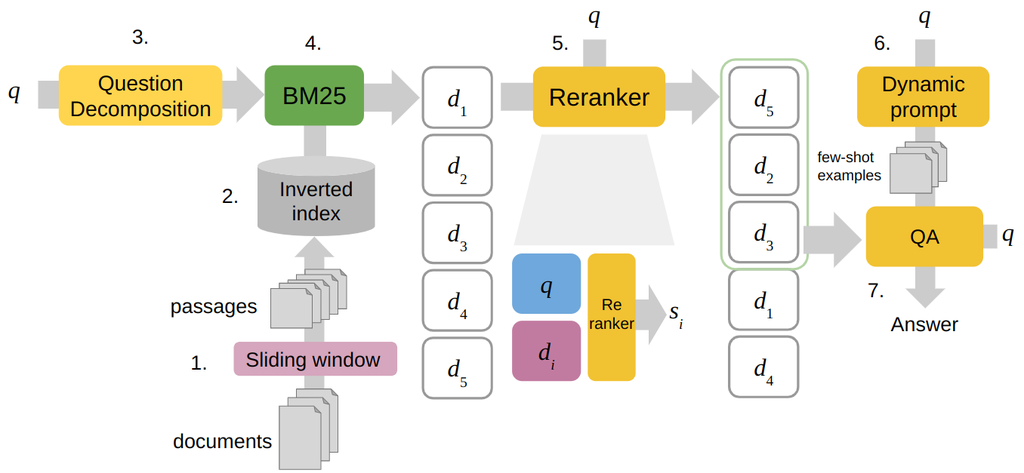

# Installing required packages

For this example, we have to install the following libraries:

**`pyserini`**: Pyserini is a Python interface for the Anserini information retrieval toolkit. It allows you to retrieve and search through large document collections using various retrieval models, including BM25. It provides a convenient way to perform efficient and effective information retrieval tasks in Python.

**`faiss-cpu`**: Faiss is a library for efficient similarity search and clustering of dense vectors. The `faiss-cpu` package is a CPU-only version of Faiss, which is needed by Pyserini for certain operations. Although we won't use dense retrieval in this notebook, `faiss-cpu` is a dependency for Pyserini.

**`pygaggle`**: Pygaggle is a Python library that provides tools and models for document reranking and passage scoring in the context of information retrieval. It includes implementation of various neural reranking models, including monoT5. By installing `git+https://github.com/castorini/pygaggle.git`, you are installing the pygaggle library from the GitHub repository.

**`transformers`**: Transformers is a popular Python library developed by Hugging Face, providing a wide range of pre-trained models for natural language processing tasks, including text classification, question answering, and language generation. By installing `transformers` with the `--upgrade` flag, you are ensuring that you have the latest version of the library.

**`openai`**: OpenAI is an organization focused on developing and promoting artificial intelligence technologies. The `openai` package provides tools and APIs to interact with OpenAI models, including GPT-3.5-turbo. By installing `openai`, you gain access to the OpenAI API and can make requests to the GPT-3.5-turbo model for natural language processing tasks.

**`sentence-transformers`**: Sentence-transformers is a Python library that provides tools for computing sentence embeddings, which are dense vector representations of sentences. These embeddings can be used for various tasks, including semantic similarity, clustering, and retrieval. By installing `sentence-transformers`, you can leverage the functionality of this library for selecting examples for prompts, among other use cases.

```python
!pip install pyserini  # To retrieve documents using BM25
!pip install faiss-cpu  # Needed by pyserini, but we will not use dense retrieval in this notebook.
!pip install git+https://github.com/castorini/pygaggle.git # to rerank with monoT5
!pip install transformers --upgrade # Used by the reranker and QA models
!pip install openai # to perform gpt-3.5-turbo requests
!pip install sentence-transformers # used for selecting examples for the prompts
```

[output not shown]

[output cut: 22 more lines]

[output not shown]

By running **`!pip freeze`**, we can quickly see a snapshot of all the installed packages and their versions in our Python environment. This information is useful for sharing project dependencies, ensuring reproducibility, and troubleshooting package compatibility issues.

```python
!pip freeze
```

[output not shown]

[output cut: 376 more lines]

[output not shown]

The code below sets the preferred encoding pattern to "UTF-8" by overriding the behavior of the **`locale.getpreferredencoding`** function. This can help avoid encoding-related issues when processing or manipulating text data, especially when dealing with questions with special characters from IIRC.

```python
# set preferred encoding pattern
import locale
def getpreferredencoding(do_setlocale = True):
    return "UTF-8"
locale.getpreferredencoding = getpreferredencoding
```

# Setting the device

In this example, we will use a GPU to speed up the processing of our model. GPUs (Graphics Processing Units) are specialized processors that are optimized for performing large-scale computations in parallel. By using a GPU, we can accelerate the training and inference of a machine learning model, which can significantly reduce the time required to complete these tasks.

Before we begin, we need to check whether a GPU is available and select it as the default device for our PyTorch operations. This is because PyTorch can use either a CPU or a GPU to perform computations, and by default, it will use the CPU.

For using a GPU in Google Colab:

1. Click on the "Runtime" menu at the top of the screen.
2. From the dropdown menu, click on "Change runtime type".
3. In the popup window that appears, select "GPU" as the hardware accelerator.
4. Click on the "Save" button.

That's it! Now you can use the GPU for faster computations in your notebook.

```python
!nvidia-smi
```

```
Tue May 23 09:58:16 2023
+-----------------------------------------------------------------------------+
| NVIDIA-SMI 525.85.12    Driver Version: 525.85.12    CUDA Version: 12.0     |
|-------------------------------+----------------------+----------------------+
| GPU  Name        Persistence-M| Bus-Id        Disp.A | Volatile Uncorr. ECC |
| Fan  Temp  Perf  Pwr:Usage/Cap|         Memory-Usage | GPU-Util  Compute M. |
|                               |                      |               MIG M. |
|===============================+======================+======================|
|   0  NVIDIA A100-SXM...  Off  | 00000000:00:04.0 Off |                    0 |
| N/A   31C    P0    43W / 400W |      0MiB / 40960MiB |      0%      Default |
|                               |                      |             Disabled |
+-------------------------------+----------------------+----------------------+

+-----------------------------------------------------------------------------+
| Processes:                                                                  |
|  GPU   GI   CI        PID   Type   Process name                  GPU Memory |
|        ID   ID                                                   Usage      |
|=============================================================================|
|  No running processes found                                                 |
+-----------------------------------------------------------------------------+
```

```python
import torch

if torch.cuda.is_available():
   dev = "cuda:0"
else:
   dev = "cpu"
device = torch.device(dev)
print('Using {}'.format(device))
```

```
Using cuda:0
```

# Download data

In this notebook, we will use the test set of the [Incomplete Information Reading Comprehension (IIRC)](https://allenai.org/data/iirc) dataset, which serves as a benchmark for our task. The IIRC dataset includes questions that necessitate the model to perform reasoning across various documents to generate a comprehensive answer. It is a demanding dataset that tests the model's ability to extract pertinent information from multiple sources and synthesize it to provide accurate responses.

Additionally, we retrieve the Wikipedia articles that are used as the context for the question-answering task.

```python
# Download test set
!wget https://iirc-dataset.s3.us-west-2.amazonaws.com/iirc_test.json
# Download context articles
!wget https://iirc-dataset.s3.us-west-2.amazonaws.com/context_articles.tar.gz
!tar -xf context_articles.tar.gz
```

```
--2023-05-23 09:58:20--  https://iirc-dataset.s3.us-west-2.amazonaws.com/iirc_test.json
Resolving iirc-dataset.s3.us-west-2.amazonaws.com (iirc-dataset.s3.us-west-2.amazonaws.com)... 52.218.193.9, 52.218.235.25, 52.218.169.57, ...
Connecting to iirc-dataset.s3.us-west-2.amazonaws.com (iirc-dataset.s3.us-west-2.amazonaws.com)|52.218.193.9|:443... connected.
HTTP request sent, awaiting response... 200 OK
Length: 2874825 (2.7M) [application/json]
Saving to: ‘iirc_test.json’

iirc_test.json      100%[===================>]   2.74M  2.33MB/s    in 1.2s

2023-05-23 09:58:21 (2.33 MB/s) - ‘iirc_test.json’ saved [2874825/2874825]

--2023-05-23 09:58:22--  https://iirc-dataset.s3.us-west-2.amazonaws.com/context_articles.tar.gz
Resolving iirc-dataset.s3.us-west-2.amazonaws.com (iirc-dataset.s3.us-west-2.amazonaws.com)... 52.218.193.9, 52.218.235.25, 52.218.169.57, ...
Connecting to iirc-dataset.s3.us-west-2.amazonaws.com (iirc-dataset.s3.us-west-2.amazonaws.com)|52.218.193.9|:443... connected.
HTTP request sent, awaiting response... 200 OK
Length: 385263479 (367M) [application/x-gzip]
Saving to: ‘context_articles.tar.gz’

context_articles.ta 100%[===================>] 367.42M  17.4MB/s    in 23s

2023-05-23 09:58:45 (16.0 MB/s) - ‘context_articles.tar.gz’ saved [385263479/385263479]
```

# 1. Sliding window

In this step, we perform document segmentation to divide the input documents into smaller segments or passages. This segmentation process aids in breaking down lengthy texts into more manageable units, allowing for more efficient processing and analysis.

This approach is particularly beneficial when dealing with large and complex documents that contain a wealth of information spread across different sections.

First, let's check the dataset size.

```python
import json

test_set = json.load(open('iirc_test.json','r'))
context_articles = json.load(open("context_articles.json",'r'))

print("Test set size:", len(test_set))
print("Total context articles",len(context_articles))
```

```
Test set size: 514
Total context articles 56550
```

For experimental purposes and to optimize processing time, we limit the number of context articles to only those used in the test set. This approach allows us to focus on a specific subset of articles that are relevant to the evaluation and analysis of our model's performance.

To remove HTML tags from the text, we utilize the **`BeautifulSoup`** library. This library provides efficient and reliable methods for parsing and manipulating HTML, allowing us to extract the underlying textual content and discard any unnecessary markup or formatting. By removing HTML tags, we can ensure that our analysis and processing are based solely on the textual information contained within the documents, without any distractions or interference from the HTML structure.

```python
from tqdm import tqdm
from bs4 import BeautifulSoup

used_articles = {}
for item in tqdm(test_set):
    for link in item['links']:
        if link['target'].lower() in context_articles and link['target'].lower() not in used_articles:
            text = context_articles[link['target'].lower()]
            soup = BeautifulSoup(text)
            used_articles[link['target'].lower()] = soup.get_text()
print("New context articles total:",len(used_articles))
```

```
New context articles total: 6523
```

In this example, we segment the text based on the number of sentences using a sliding window approach. The purpose of segmentation is to break down the document into smaller segments, making it easier for analysis or processing.

The code below demonstrates the implementation of the text segmentation process. Let's go through it step by step:

1. Importing necessary libraries: The code imports the `tqdm` library for creating progress bars and the `spacy` library for natural language processing tasks.
2. Setting up the spaCy pipeline: An instance of the spaCy language model is created using `spacy.blank("en")`, which initializes a blank English language model. The 'sentencizer' component is added to the pipeline using `nlp.add_pipe('sentencizer')`. This component is responsible for sentence segmentation, i.e., splitting the text into individual sentences.
3. Defining parameters: The code defines two parameters for segmentation: `stride` and `max_length`. `Stride` determines the step size between consecutive segments, while `max_length` specifies the maximum number of sentences in each segment.
4. Window function: The `window` function takes a document as input and performs the segmentation. It extracts the content of the document and processes it using the spaCy pipeline. The sentences in the document are extracted using a list comprehension and stored in the `sentences` variable.
5. Segmenting the document: The code then iterates over the sentences using a loop with a step size defined by `stride`. It constructs a segment by concatenating `max_length` consecutive sentences using `' '.join(sentences[i:i + max_length])`. The segment is added to the `segments` list along with the title and other details of the document.
6. Handling the end of the document: If the index `i + max_length` exceeds the length of the sentences, indicating that there are no more sentences to process, the loop is terminated using `break`.
7. Returning the segments: The `window` function returns the list of segments extracted from the document.
8. Segmentation for all documents: The code initializes an empty list `all_segments` to store the segments from all documents. It then iterates over the `used_articles` using `tqdm` for progress visualization. For each document, the `window` function is called to obtain segments, which are then appended to `all_segments`.
9. Displaying the number of segments: Finally, the code prints the total number of segments obtained using `len(all_segments)`.

In summary, the provided code segment demonstrates how to perform text segmentation by the number of sentences using the spaCy library. The resulting segments allow for more manageable analysis and processing of the document's content.

```python
from tqdm import tqdm
import spacy

nlp = spacy.blank("en")
nlp.add_pipe('sentencizer')

stride = 2
max_length = 3

def window(document, stride=stride, max_length=max_length):
    segments = []
    doc_text = document['content']
    doc = nlp(doc_text)
    sentences = [sent.text.strip() for sent in doc.sents]
    for i in range(0, len(sentences), stride):
        segment = ' '.join(sentences[i:i + max_length])
        segments.append({
            "title": document['title'],
            "contents": document['title']+". "+segment,
            "segment": segment
        })
        if i + max_length >= len(sentences):
            break
    return segments

all_segments = []

for title in tqdm(used_articles):
    segments = window({
        "title": title,
        "content":used_articles[title]
    })
    all_segments += segments
print("\nNumber of segments:", len(all_segments))
```

```
Number of segments: 496943
```

After segmenting the text, we proceed to write the segments into a jsonlines file. This file format is chosen because it is compatible with the pyserini library, which will be used to create a searchable index from the segments.

```python
import os
os.mkdir("iirc_segments")

f = open("iirc_segments/contents.jsonl",'w')

for i, doc in enumerate(all_segments):
    doc['id'] = i
    if doc['segment'] != "": # exclude empty segments
        f.write(json.dumps(doc)+"\n")
f.close()
```

# 2. Inverted Index

In the context of information retrieval, indexing refers to the process of creating an inverted index. An inverted index is a data structure that enables efficient retrieval of passages or documents that contain one or more words present in a query or question.

Using Pyserini, we can create an inverted index for the segmented passages. This indexing process involves analyzing the text, extracting relevant terms or words, and associating them with the corresponding passages or documents. By building an inverted index, we establish a mapping between words and their occurrences in the collection of passages.

The inverted index allows for faster retrieval of passages or documents that match a given query by leveraging the pre-computed mapping. Instead of scanning the entire collection, the index provides a quick lookup mechanism to identify the relevant passages that contain the query terms. This significantly improves the efficiency and speed of the information retrieval process.

```python
!python3 -m pyserini.index  -collection JsonCollection \
                            -generator DefaultLuceneDocumentGenerator \
                            -threads 1 \
                            -input iirc_segments \
                            -index iirc_index \
                            -storeRaw
```

[output not shown]

# 3. Question Decomposition

In this section, we aim to decompose the original question into self-contained sub-questions. Decomposing the question allows us to break down complex queries into smaller, more manageable parts, which can enhance the accuracy and granularity of our answers. By identifying the key components and sub-topics within the question, we can address each sub-question individually and provide more comprehensive responses.

## Using OpenAI API

First, let's define the interface for accessing the OpenAI API.

To use OpenAI API, we need to set our API key and import the OpenAI module. In the given code, we have the `OPENAI_KEY` variable which we can set to our OpenAI API key. After that, we can use the `openai.api_key` method to set the API key for our session.

The function `generate_chat` takes in a list of messages and generates a response using the OpenAI Chat API. The `model` parameter specifies which model to use for generating the response. In the given code, we have used the `gpt-3.5-turbo` model. However, we can also use `gpt-4`.

**IMPORTANT:** It's important to note that there are costs associated with using the OpenAI API, so we need to choose the appropriate model and set the parameters carefully to avoid unnecessary expenses.

```python
import os
import openai

OPENAI_KEY = "" # @param set your OpenAI API key here

openai.api_key = OPENAI_KEY

def generate_chat(messages,model="gpt-3.5-turbo"):
  response = openai.ChatCompletion.create(
    model=model,
    messages=messages,
    temperature=0
  )
  return response["choices"][0]['message']['content']
```

## Question decomposition examples

The code below contain examples of questions and sub-questions from the [StrategyQA](https://allenai.org/data/strategyqa) dataset. We will use these examples as few-shot demonstration for question decomposition using GPT-3.5-turbo.

```python
question_decomposition_examples = [
    {
        "question": "Is Hamlet more common on IMDB than Comedy of Errors?",
        "subquestions": [
            "How many listings of Hamlet are there on IMDB?",
            "How many listing of Comedy of Errors is there on IMDB?"
        ]
    },
    {
        "question": "Do the telescopes at Goldstone Deep Space Communications Complex work the night shift?",
        "subquestions": [
            "What hours are typically considered the night shift?",
            "What hours do the telescopes at Goldstone Deep Space Communications Complex run?"
        ]
    },
    {
        "question": "Is it legal for a licensed child driving Mercedes-Benz to be employed in US?",
        "subquestions": [
            "What is the minimum driving age in the US?",
            "What is the minimum age for someone to be employed in the US?"
        ]
    },
    {
        "question": "Would a sofer be a bad job for a vegan?",
        "subquestions": [
            "What does a sofer do?",
            "What are the dietary restrictions of a vegan?"
        ]
    },
    {
        "question": "Hydrogen's atomic number squared exceeds number of Spice Girls?",
        "subquestions": [
            "What is the atomic number of hydrogen?",
            "How many Spice Girls are there?"
        ]
    }
]
```

## Performing question decomposition

The code below performs question decomposition. It defines the question_decomposition function.

- The **`question_decomposition`** function takes a question as input and decomposes it into self-contained sub-questions.
- It starts by defining an instruction message template that instructs the assistant to break down a specific question into sub-questions.
- It creates a list of messages containing alternating user and assistant messages. The user messages contain the instruction template with specific questions, and the assistant messages provide the sub-questions as responses.
- After generating the chat conversation using the **`generate_chat`** function (OpenAI API call), the response is obtained.
- The response is then processed using the regular expression pattern defined earlier to extract the sub-questions. Finally, the extracted sub-questions are returned as a list.

```python
import re

def question_decomposition(question):
    """
    Decomposes the given question into self-contained sub-questions using ChatGPT.

    Args:
        question (str): The question to be decomposed.

    Returns:
        list: A list of self-contained sub-questions extracted from the original question.

    Example:
        question = "What are the advantages and disadvantages of renewable energy sources?"
        subquestions = question_decomposition(question)
        print(subquestions)
        # Output: ['What are the advantages of renewable energy sources?', 'What are the disadvantages of renewable energy sources?']
    """


    # Defining the instruction message template
    instruction = f"Please decompose the following question into self-contained sub-questions."

    # Creating a list of user and assistant messages containing the main question, demonstration examples, and the user message with the target question.
    messages = []
    messages.append({"role": "system", "content": instruction})
    for example in question_decomposition_examples:
        messages.append({"role": "user", "content": example["question"]})
        messages.append({"role": "assistant", "content": ' '.join(example["subquestions"])})

    messages.append({"role": "user", "content": question})

    # Generating the chat conversation
    response = generate_chat(messages)

    # Extracting the sub-questions using a regular expression pattern
    subquestions_pattern = re.compile(r'(?:^|\s)([^.?]+?[.?])')
    extracted_subquestions = subquestions_pattern.findall(response)

    # Cleaning and returning the sub-questions as a list
    return [sq.strip() for sq in extracted_subquestions]
```

Let's use the below question as an example.

```python
question = "Which stadium where Brunt played can hold more people, The Hawthorns or White Hart Lane?" #@param ["Which stadium where Brunt played can hold more people, The Hawthorns or White Hart Lane?","How many years were there between Pompeii's destruction and the discovery of the Maya site of Cerén?","How long had Eddie Waitkus been playing professionally when he was traded to the Phils?","How old was Licerio Ger\u00f3nimo when Private Bonifacio Mariano killed General Henry Ware Lawton?","How old was Henry Ware Lawton when Private Bonifacio Mariano killed him?"]
```

```python
subquestions = question_decomposition(question)

print(f"Main question: {question}")
print("Decompositions:")
subquestions
```

```
Main question: Which stadium where Brunt played can hold more people, The Hawthorns or White Hart Lane?
Decompositions:
```

```
['What is the seating capacity of The Hawthorns stadium?',
 'What is the seating capacity of White Hart Lane stadium?']
```

# 4. Sparse Retrieval

This step involves retrieving a set of relevant passages for a given question using the BM25 algorithm.

Using the BM25 algorithm, we retrieve the top k (e.g., k=100) passages that are deemed most relevant to the question. BM25, which stands for Best Match 25, is a widely used ranking function in information retrieval. It calculates a relevance score for each passage based on the frequency of query terms within the passage and their distribution across the entire collection of passages.

By retrieving a subset of passages, we aim to narrow down the focus to the most promising and informative content for further analysis. These retrieved passages serve as potential candidates for subsequent stages of our question answering system, such as passage reranking and answer extraction.

## Initializing the SimpleSearcher

To facilitate the retrieval of information from our inverted index, we initialize the SimpleSearcher module from pyserini. This module allows us to perform efficient search operations on our indexed data.

In the cell below, we instantiate the **`SimpleSearcher`** object and specify the location of our inverted index using the **'./iirc_index'** path. This step enables the **`SimpleSearcher`** to access and interact with the indexed data stored in the specified directory.

```python
from pyserini.search import SimpleSearcher

searcher = SimpleSearcher('./iirc_index')
```

```
SimpleSearcher class has been deprecated, please use LuceneSearcher from pyserini.search.lucene instead
```

## Retrieving

To retrieve relevant information for the given question, we utilize the SimpleSearcher module and execute a search operation on our indexed data. The code snippet below demonstrates the process:

In this code, we initiate a search using the `searcher` object and pass the `question` as the query parameter. We specify `k=100` to retrieve up to 100 passages that are most relevant to the question.

The search results, stored in the `hits` variable, contain information about each retrieved passage, including the passage's score indicating its relevance to the query. We iterate over the top 10 results using the `enumerate` function and access the text content of each hit using the `json.loads(hit.raw)['segment']` statement. Finally, we print the hit's index, document ID, score, and text content.

By retrieving and displaying the relevant passages, we can gain insights into potential answers or useful information for further analysis or processing.

```python
import json

hits = searcher.search(question, k=100)

for i, hit in enumerate(hits[:10]):
    text = json.loads(hit.raw)['segment']
    print(f'{i+1:2}{hit.docid:8} {hit.score:.5f}  {text}')
```

```
 14256     16.95240  On 28 April 2017, it was announced that Tottenham would play all its home matches in the 2017–18 season at Wembley Stadium, in order to complete the demolition of White Hart Lane and the construction of the new stadium. The new stadium was scheduled to open for the start of the …
 23702     16.59960  Domestic fixtures of the 2016–17 season continued to be played at the Lane, but demolition of the rest of the stadium started the day after the last game of the season, and White Hart Lane was completely demolished by the end of July 2017. Tottenham Hotspur Stadium. In October 2…
 34255     16.56360  This therefore allowed widening of the High Road pavement leading to the new stadium by demolishing three buildings (Edmonton Dispensary, The Red House, and the former White Hart Public House). Construction work on the stadium began in early 2016. On 28 April 2017, it was announ…
 44223     16.11340  Ultimately the club's owners, ENIC Group, decided to focus solely on the ongoing redevelopment plan for White Hart Lane as part of the Northumberland Development Project. Sections of the North and East Stands at the north-east corner were removed in 2016 to allow construction of…
 54220     16.02030  The renovation, and the addition of a second tier to the Members' (North) Stand on Paxton Road, was completed in 1998, leaving the stadium with a capacity of 36,240. The stadium would stay in this form, bar some minor adjustments, until 2016, when the north-east corner of the st…
 64238     15.49350  The player with the most appearances at White Hart Lane is Steve Perryman who played 436 games, while Jimmy Greaves scored the most goals, with 176 goals at The Lane. The highest attendance recorded at The Lane was 75,038 for the Sixth Round FA Cup tie against Sunderland, 5 Marc…
 74222     15.21070  Talks began over the redevelopment and future of White Hart Lane, and many stadium designs and ideas were rumoured in the media, with the possibility of Tottenham Hotspur moving home also mooted. However, a move to Wembley Stadium was ruled out by the club, as was talk of moving…
 84221     15.09680  New stadium. By the turn of the millennium, the capacity of White Hart Lane had fallen significantly behind compared to other major Premier League clubs who had plans to expand further (for example, proposed development of Old Trafford had a projected capacity of 79,000 while Ar…
 94184     15.08360  The new ground was never officially named, although names such as Gilpin Park and Percy Park were suggested. In its early days it was normally referred to as the Hotspur's or Spurs' Ground by the club or the High Road Ground by the public, in time it became popularly known as Wh…
104224     15.08330  As this reduced the stadium capacity below that required for European games, Tottenham Hotspur played every European home game in 2016–17 at Wembley Stadium. On 14 May 2017, White Hart Lane hosted its final match in a Premier League encounter between Tottenham Hotspur and Manche…
```